# Resistance test in liquid - Static & short term

```r
library(tidyverse)
library(broom)
library(cowplot)
library(here)
library(caTools)
```

# Reduction of Bacterial Growth

Based on method described by Poullain et al. (2008). The evolution of specificity in evolving and coevolving antagonistic interactions between a bacteria and its phage. Evolution: International Journal of Organic Evolution, 62(1), 1-11.

> The reduction in bacterial absorbance “RBG” induced by phage i on bacterial colony j, was calculated as RBGij=[abs630(t= 20) − abs630(t= 0)]ij/[abs630(t= 20) − abs630(t= 0)]controlj. Each cross‐infection was performed in triplicate at the same time. Thus only data corresponding to RBGij < 0.95 were considered in the analyses (positive infection). Data are presented as 1 – RBGi for more clarity.

In this round of the experiment we are looking into the incubation time of a static plate for endpoint assay. This trial was carried out using colonies from WLO-L2 veg from T=day2.

# static plate data

Plot

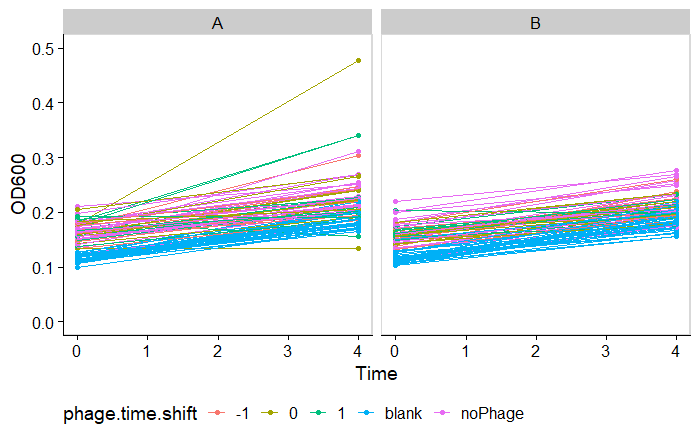

```r
d.long%>%
  # remove dilution data (marked as time -1)
  filter(Time>=0)%>%
  # remove data of vortexed plate from endpoint
  filter(!vortex)%>%
  ggplot(aes(x=Time, y=OD600, color=phage.time.shift, group=well))+
  geom_point()+
  geom_line()+
  facet_grid(.~rep)+
  theme_cowplot()+
  panel_border()+
  theme(legend.position = "bottom")+
  ylim(0,0.5)
```

Effect of vortex

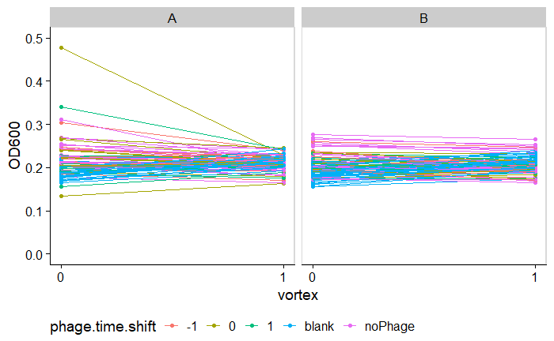

```r
d.long%>%
  # remove dilution data (marked as time -1)
  filter(Time==4)%>%
  # remove data of vortexed plate from endpoint
  mutate(vortex=if_else(vortex, 1,0))%>%
  # pivot_wider(names_from = vortex, values_from=OD600)
  ggplot(aes(x=vortex, y=OD600, color=phage.time.shift, group=well))+
  geom_point()+
  geom_line()+
  facet_grid(.~rep)+
  theme_cowplot()+
  panel_border()+
  theme(legend.position = "bottom")+
  scale_x_continuous(breaks = c(0,1))+
  ylim(0,0.5)
```

Vortex makes things mre simmilar. Pot with vortexed data

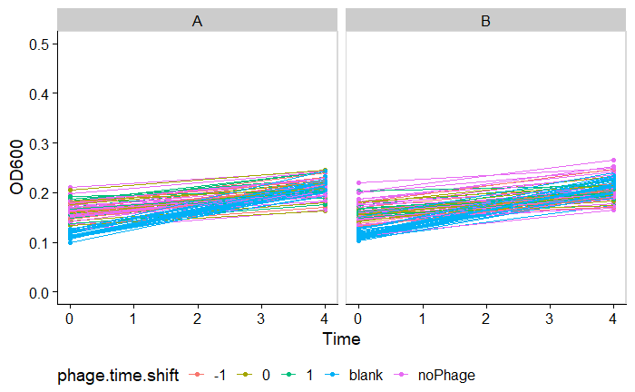

```r
d.long%>%
  # remove dilution data (marked as time -1)
  filter(Time>=0)%>%
  # remove data of non-vortexed plate from endpoint
  filter(Time==0 | vortex)%>%
  ggplot(aes(x=Time, y=OD600, color=phage.time.shift, group=well))+
  geom_point()+
  geom_line()+
  facet_grid(.~rep)+
  theme_cowplot()+
  panel_border()+
  theme(legend.position = "bottom")+
  ylim(0,0.5)
```

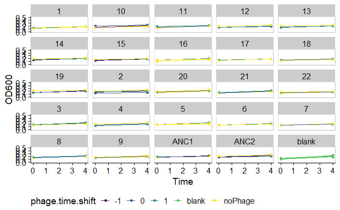

```r
d.long%>%
  # remove dilution data (marked as time -1)
  filter(Time>=0)%>%
  # remove data of non-vortexed plate from endpoint
  filter(Time==0 | vortex)%>%
  #   # remove data of vortexed plate from endpoint
  # filter(!vortex)%>%
  ggplot(aes(x=Time, y=OD600, color=phage.time.shift, group=well))+
  geom_point()+
  geom_line()+
  facet_wrap(~host)+
  theme_cowplot()+
  panel_border()+
  theme(legend.position = "bottom")+
  ylim(0,0.5)+
  scale_color_viridis_d()+
  ggsave2(here("plots", "WLO_L2_D2_V_liquid.pdf"),width = 11,height = 8.5)
```

Looks like it diid not work. There is no difference in Anc control.